# Regression project

In this project we will implement several models to predict the crime rate in a new city in the US, while assessing a possible overfitting problem. The dataset used is the crime data from http://www.statsci.org/data/general/uscrime.txt.

We will implement the following models: (a) Multiple linear regression (b) Multiple linear regression with principal components

## EXPLORATORY DATA ANALYSIS

First, we load the data and libraries.

```r
#We load the libraries
library(tidyverse)
library(GGally)
```

```r
library(corrplot)
library(outliers)
library(lmtest)
library(caret)
library(factoextra)
#Digit configuration in R
options(digits = 7,
        scipen = 999)

#We load the data
rm(list=ls())

data = read.table("uscrime.txt",header = T)
```

After loading the data, we might want to use implement descriptive statistics.

```r
#Descriptive analysis
summary(data)
```

```
##        M               So               Ed             Po1
##  Min.   :11.90   Min.   :0.0000   Min.   : 8.70   Min.   : 4.50
##  1st Qu.:13.00   1st Qu.:0.0000   1st Qu.: 9.75   1st Qu.: 6.25
##  Median :13.60   Median :0.0000   Median :10.80   Median : 7.80
##  Mean   :13.86   Mean   :0.3404   Mean   :10.56   Mean   : 8.50
##  3rd Qu.:14.60   3rd Qu.:1.0000   3rd Qu.:11.45   3rd Qu.:10.45
##  Max.   :17.70   Max.   :1.0000   Max.   :12.20   Max.   :16.60
##       Po2               LF              M.F              Pop
##  Min.   : 4.100   Min.   :0.4800   Min.   : 93.40   Min.   :  3.00
##  1st Qu.: 5.850   1st Qu.:0.5305   1st Qu.: 96.45   1st Qu.: 10.00
##  Median : 7.300   Median :0.5600   Median : 97.70   Median : 25.00
##  Mean   : 8.023   Mean   :0.5612   Mean   : 98.30   Mean   : 36.62
##  3rd Qu.: 9.700   3rd Qu.:0.5930   3rd Qu.: 99.20   3rd Qu.: 41.50
##  Max.   :15.700   Max.   :0.6410   Max.   :107.10   Max.   :168.00
##        NW              U1                U2            Wealth
##  Min.   : 0.20   Min.   :0.07000   Min.   :2.000   Min.   :2880
##  1st Qu.: 2.40   1st Qu.:0.08050   1st Qu.:2.750   1st Qu.:4595
##  Median : 7.60   Median :0.09200   Median :3.400   Median :5370
##  Mean   :10.11   Mean   :0.09547   Mean   :3.398   Mean   :5254
##  3rd Qu.:13.25   3rd Qu.:0.10400   3rd Qu.:3.850   3rd Qu.:5915
##  Max.   :42.30   Max.   :0.14200   Max.   :5.800   Max.   :6890
##       Ineq            Prob              Time           Crime
##  Min.   :12.60   Min.   :0.00690   Min.   :12.20   Min.   : 342.0
##  1st Qu.:16.55   1st Qu.:0.03270   1st Qu.:21.60   1st Qu.: 658.5
##  Median :17.60   Median :0.04210   Median :25.80   Median : 831.0
##  Mean   :19.40   Mean   :0.04709   Mean   :26.60   Mean   : 905.1
##  3rd Qu.:22.75   3rd Qu.:0.05445   3rd Qu.:30.45   3rd Qu.:1057.5
##  Max.   :27.60   Max.   :0.11980   Max.   :44.00   Max.   :1993.0
```

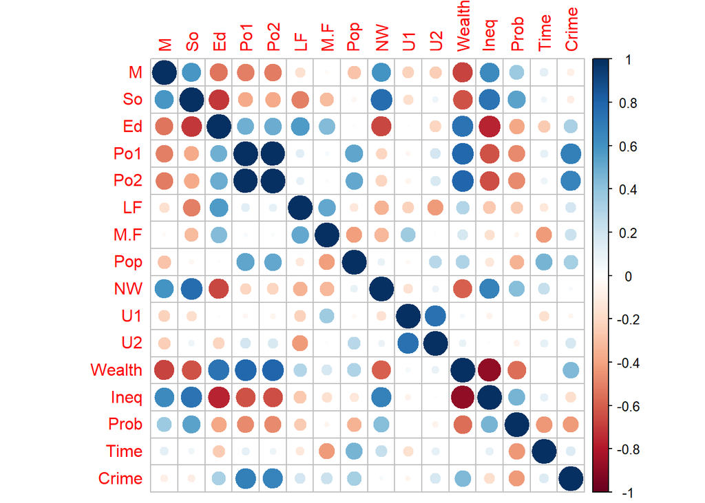

```r
#Correlation plot
corrplot(cor(data))
```

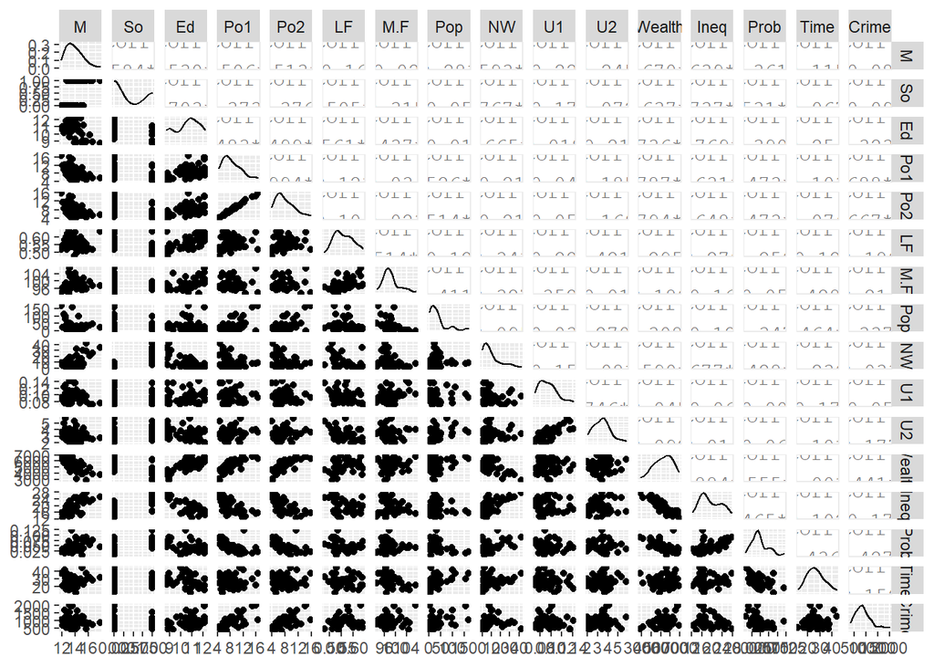

```r
#Descriptive plots
ggpairs(data)
```

From the above results we can observe some things. First, the range of Crime is between 342 and 1993. In terms of the relation of Crime with other predictors, we observe that the most significant correlations of the response variable are Po1 and Po2 (per capita expenditure on police in 1959 and 1960).

In total, the variable Crime has a significant correlation (with a 95% confidence) with the following variables: Ed, Po1, Po2, Pop, Wealth and Prob. It is possible that such correlation is probably inflated by multicollinearity.

Here, we can observe that Wealth appears to be highly correlated with Ed, P1, P2 and Inequality. Also, there appear to be a high correlation among P1 and P2, which are basically the same variable since the correlation coefficient is very close to 1.

An important aspect, is that the variables are not scaled. In other words, the range of every value is different, and they are not centered around zero. For the purpose of this problem, we will ignore this fact, but this could be relevant depending on how the linear regression is fitted (e.g. which optimization algorithm is being implemented).

On the other hand, there are no missing values. In terms of outliers, we use a statistical test to look for outliers. We can conclude with a 95% confidence that neither could be considered outliers. On the other hand, there are no missing values.

```r
#Missing values
data %>%
  sapply(FUN = function(x) sum(is.na(x)))
```

```
##      M     So     Ed    Po1    Po2     LF    M.F    Pop     NW     U1     U2
##      0      0      0      0      0      0      0      0      0      0      0
## Wealth   Ineq   Prob   Time  Crime
##      0      0      0      0      0
```

```r
#Outliers tests
grubbs.test(data$Crime)
```

```
##
##  Grubbs test for one outlier
##
## data:  data$Crime
## G = 2.81287, U = 0.82426, p-value = 0.07887
## alternative hypothesis: highest value 1993 is an outlier
```

```r
grubbs.test(data$Crime,opposite = T)
```

```
##
##  Grubbs test for one outlier
##
## data:  data$Crime
## G = 1.45589, U = 0.95292, p-value = 1
## alternative hypothesis: lowest value 342 is an outlier
```

## MULTIPLE LINEAR REGRESSION

```r
#Set seed
set.seed(123)

#Data partition
id = createDataPartition(data$Crime, p = 0.9, list = F)
train = data[id, ]
test = data[-id, ]
```

We estimate the first model, that is: Crime as a function of every other variable, even when their correlation is not significant. To implement this, we use a leave-one-out-cross-validation approach with caret package.

```r
#Implement a cross-validation
train_control = trainControl(method="LOOCV")

#We estimate the model
model = train(Crime~.,
               data = train,
               method  = "lm",
               trControl = train_control)

#Cross-validated R2
model$results$Rsquared
```

```
## [1] 0.4608877
```

```r
#Coefficients of the full model
summary(model$finalModel)
```

```
##
## Call:
## lm(formula = .outcome ~ ., data = dat)
##
## Residuals:
##     Min      1Q  Median      3Q     Max
## -414.76 -100.52  -31.93  117.46  506.99
##
## Coefficients:
##                Estimate  Std. Error t value Pr(>|t|)
## (Intercept) -5695.48797  1809.20132  -3.148  0.00398 **
## M              82.99532    45.36818   1.829  0.07841 .
## So            -39.16158   167.88339  -0.233  0.81731
## Ed            183.72070    82.06129   2.239  0.03361 *
## Po1           183.83794   115.72130   1.589  0.12379
## Po2          -105.69574   128.01979  -0.826  0.41626
## LF           -947.78316  1641.26283  -0.577  0.56841
## M.F            20.27311    24.73527   0.820  0.41962
## Pop            -0.66055     1.44079  -0.458  0.65029
## NW              5.55158     7.13441   0.778  0.44325
## U1          -6266.26103  4689.80417  -1.336  0.19265
## U2            169.40816   100.55165   1.685  0.10356
## Wealth          0.08193     0.12545   0.653  0.51922
## Ineq           69.43364    24.69831   2.811  0.00908 **
## Prob        -6335.13268  3390.62919  -1.868  0.07259 .
## Time           -5.31996     8.02990  -0.663  0.51325
## ---
## Signif. codes:  0 '***' 0.001 '**' 0.01 '*' 0.05 '.' 0.1 ' ' 1
##
## Residual standard error: 221.3 on 27 degrees of freedom
## Multiple R-squared:  0.7947, Adjusted R-squared:  0.6807
## F-statistic: 6.969 on 15 and 27 DF,  p-value: 0.000007421
```

From that model we can observe that, with a 95% confidence, Ed and Ineq are significant to explain Crime.

In terms of the quality of the model we can observe the following.

The proportion of the variance that is explained by the model, adjusted by the number of parameters estimated (adjusted R-squared) is 0.6807. However, when we observe the cross-validated R2, that number drops to 0.4608877. This indicates over-fitting in the dataset.

Of course, since we only have 43 observations and 16 variables it is very likely that we are experiencing some form of overfitting. To solve this potential problem, we will implement a multiple regression model with principal components (PCA).

## PRINCIPAL COMPONENTS ANALYSIS

Given those results, we proceed to estimate the principal components with the scaled data.

```r
#We define a numerical matrix excluding the response
num = train %>% select(-Crime)

#We implement the PCA model
model.pca = prcomp(num, center=TRUE, scale.=TRUE)
summary(model.pca)
```

```
## Importance of components:
##                         PC1    PC2    PC3     PC4     PC5     PC6     PC7
## Standard deviation     2.51 1.7070 1.4037 1.01428 0.90568 0.75022 0.58026
## Proportion of Variance 0.42 0.1943 0.1314 0.06858 0.05468 0.03752 0.02245
## Cumulative Proportion  0.42 0.6143 0.7457 0.81424 0.86892 0.90644 0.92889
##                            PC8    PC9    PC10    PC11    PC12    PC13    PC14
## Standard deviation     0.52574 0.4790 0.41755 0.40514 0.31287 0.25424 0.23434
## Proportion of Variance 0.01843 0.0153 0.01162 0.01094 0.00653 0.00431 0.00366
## Cumulative Proportion  0.94732 0.9626 0.97424 0.98518 0.99171 0.99601 0.99968
##                           PC15
## Standard deviation     0.06974
## Proportion of Variance 0.00032
## Cumulative Proportion  1.00000
```

```r
#We obtain the eigenvector matrix
model.pca$rotation
```

```
##                 PC1         PC2          PC3         PC4         PC5
## M      -0.287173192  0.05737262  0.193607114 -0.32131885 -0.21068793
## So     -0.331635856 -0.14617857  0.002027524 -0.24986773  0.12823825
## Ed      0.337583716  0.22442962  0.007232703 -0.04474065  0.06860224
## Po1     0.305192210 -0.26226662  0.045686283 -0.37123708  0.20052861
## Po2     0.306662753 -0.25707453  0.047101999 -0.35921832  0.24295309
## LF      0.182384316  0.32611651  0.270933852 -0.21285308 -0.30331339
## M.F     0.136503601  0.37821763 -0.162188201 -0.52753890 -0.26883608
## Pop     0.107915845 -0.45423176  0.101147334 -0.03257297  0.10812575
## NW     -0.292757969 -0.20377966  0.088467224 -0.42279174  0.02074288
## U1      0.036356666 -0.01204913 -0.659109345 -0.03383696 -0.26424628
## U2     -0.001494293 -0.29502432 -0.569714620 -0.08842963 -0.14946365
## Wealth  0.378040925 -0.06687433 -0.002595777 -0.02149989 -0.01001155
## Ineq   -0.358171238 -0.03255270  0.011770950 -0.17026066 -0.08779767
## Prob   -0.290759580  0.20864408 -0.150274619 -0.01255263  0.39398505
## Time   -0.009221800 -0.39572533  0.242196197  0.15320899 -0.63531858
##                PC6         PC7         PC8         PC9         PC10        PC11
## M      -0.44443527  0.50404065  0.29006587 -0.29474199  0.004815409 -0.24974611
## So     -0.12130631 -0.37864360  0.26925341  0.54126304  0.007236494 -0.23235209
## Ed     -0.05533807  0.23396238  0.01397027  0.52199199  0.141669202  0.12010285
## Po1    -0.07667729 -0.04466456 -0.12410204 -0.21318391 -0.121867981  0.18213062
## Po2    -0.10635578 -0.03432156 -0.12868052 -0.17469314 -0.047154541  0.16978345
## LF      0.53255909 -0.07528770 -0.18333065 -0.13312707  0.145623634 -0.39205233
## M.F     0.02566305 -0.08812276  0.20229150  0.14466587 -0.377064268  0.19768729
## Pop     0.54899083  0.37252436  0.51127898  0.08793796 -0.027669251 -0.07003648
## NW      0.07733865  0.15585999 -0.50580051  0.23532125  0.418256799 -0.01838652
## U1      0.06086464  0.30120116  0.04353154  0.04093863  0.345932513  0.23759054
## U2      0.04318499 -0.17142649 -0.13059038 -0.14620508 -0.190336960 -0.48144498
## Wealth -0.15296727 -0.01272330  0.07056038  0.20568907 -0.063702427 -0.36126904
## Ineq    0.30330373 -0.29091262  0.19650922 -0.15787924 -0.007496903  0.38742429
## Prob    0.22887145  0.39268826 -0.30036756  0.11146234 -0.560338940 -0.06008555
## Time   -0.05015083  0.09515715 -0.25821066  0.25932792 -0.386910187  0.19164169
##               PC12        PC13        PC14          PC15
## M       0.20213848 -0.03806699 -0.04271834 -0.0002490246
## So      0.15444573  0.42045172 -0.10727106  0.0060902065
## Ed      0.58044318 -0.28506853  0.20730180 -0.0528159728
## Po1     0.13695846  0.19691718 -0.09643713 -0.6887506760
## Po2     0.15099433  0.12499051 -0.05551672  0.7193525922
## LF      0.21433642  0.26465128 -0.13178950  0.0281580005
## M.F    -0.38932661 -0.06167189  0.23219657  0.0248429657
## Pop    -0.13740251 -0.02001764  0.15741352  0.0032007283
## NW     -0.30396673 -0.25702499  0.09502162 -0.0388542412
## U1      0.01539092  0.33183720 -0.32920405  0.0171044558
## U2      0.25259807 -0.25664298  0.30136311 -0.0058461016
## Wealth -0.24847715 -0.37726414 -0.66522483 -0.0054342033
## Ineq    0.32406676 -0.46084581 -0.35506593  0.0054078095
## Prob    0.08298690  0.07079833 -0.23374328  0.0246246805
## Time    0.10166205  0.10050309 -0.06158827  0.0374945721
```

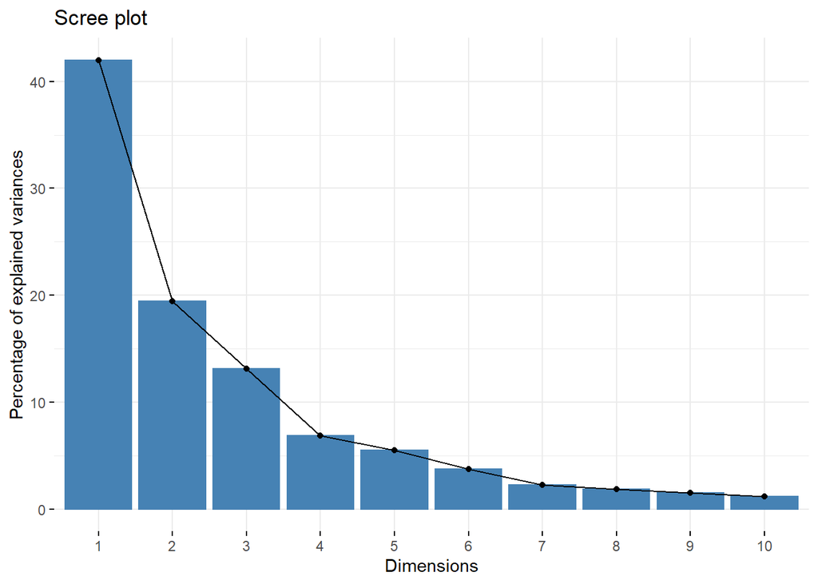

```r
#Scree plot
fviz_eig(model.pca)
```

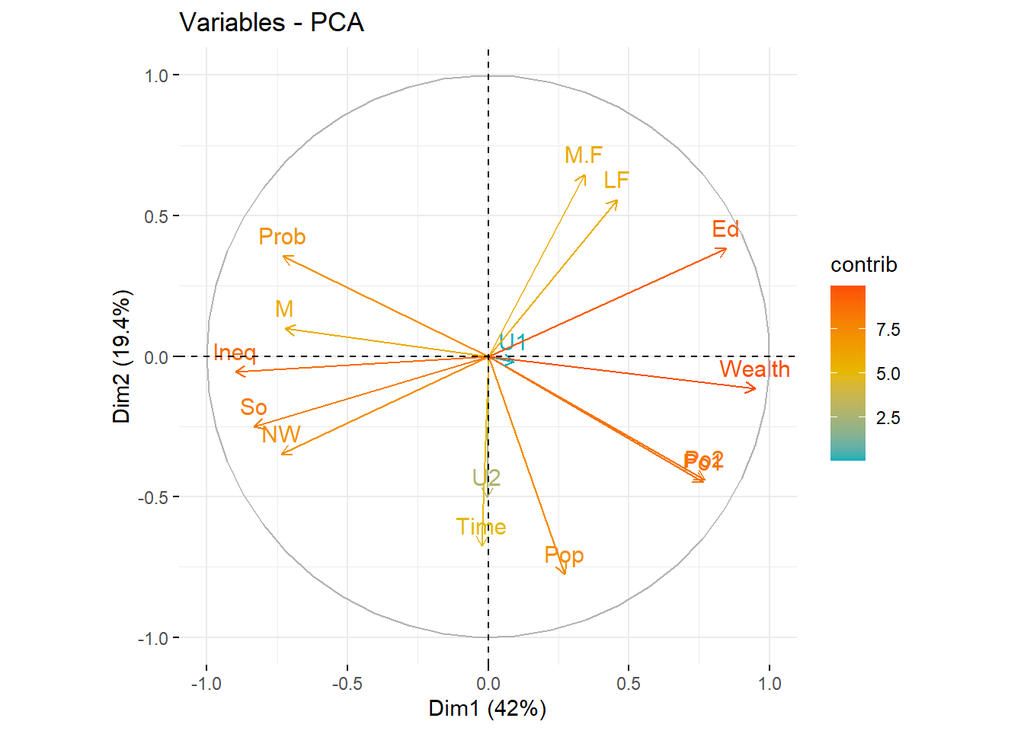

```r
#Variables PCA plot
fviz_pca_var(model.pca,col.var = "contrib",gradient.cols = c("#00AFBB", "#E7B800", "#FC4E07"))
```

Here, we can observe that the first two components explain 61.40% of the variance. If we count for the first four components, the 81.42% of the variance is captured. From the screeplot, there seems to be an inflection point (elbow) on four components.

In terms of the radial plot for the first two components, we can observe several things: (a) The variables with the biggest contribution for the two components are wealth, inequality, Ed, po1, po2.

2. There appear to be a high positive correlation between po1 and po2 and a high negative correlation between wealth and inequality.
3. The less important variables in terms of their contribution to the variance explained by this two components appear to be U1, U2. Other variables that appear less important are M.F, LF, Time, M and Prob.
4. In general, there is not a combination of two variables that are orthogonal to each other (that show zero correlation).

The question is how many components to select in order to implement the linear regression. In this case, we will select four components, but will compare the results with a cross-validation principal component regression.

Later, we will estimate a linear regression model using principal components. We will determine the number of components based on the R2. From that example, we show that four components increase the cross-validated R2 to 0.5765.

```r
#Create a sequence for R2
r2 <- numeric(15)

#Extract the crime variable
crime = as.data.frame(train$Crime)
names(crime) = "crime"

#Extract the validation R2 for regression with different number of components
for (i in 1:15) {
  pcs = as.data.frame(model.pca$x[,1:i])
  data.pca = cbind(crime,pcs)
  model = train(crime~.,data=data.pca,method="lm",trControl=train_control )
  r2[i] = model$result$Rsquared # calculate R-squared
}

#Show the results
components = seq(1,15)
r2_df = cbind(components,r2) %>% as.data.frame()

r2_df %>% filter(r2 == max(r2))
```

| components | r2 |
| --- | --- |
| 4 | 0.5764878 |

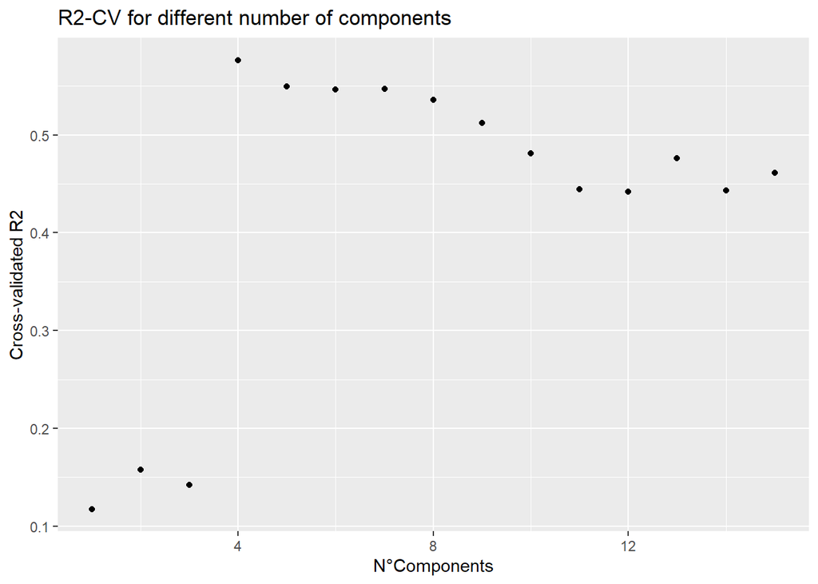

```r
#Plot the results
ggplot(data=r2_df,aes(x=components,y=r2)) + geom_point()+ ggtitle("R2-CV for different number of components") +
  xlab("N°Components") + ylab("Cross-validated R2")
```

Therefore, we estimate that the model with four components.

```r
#We extract the principal components data
pcs = as.data.frame(model.pca$x)
data.pca = cbind(crime,pcs)

#Second model: LOOCV with only four components
model.2 = train(crime~PC1+PC2+PC3+PC4,data=data.pca,method="lm",trControl=train_control)

#Cross-validated R2
model.2$results$Rsquared
```

```
## [1] 0.5764878
```

```r
#Coefficients of the full model
summary(model.2$finalModel)
```

```
##
## Call:
## lm(formula = .outcome ~ ., data = dat)
##
## Residuals:
##     Min      1Q  Median      3Q     Max
## -485.93 -149.14    9.04  129.31  423.55
##
## Coefficients:
##             Estimate Std. Error t value             Pr(>|t|)
## (Intercept)   914.65      35.86  25.503 < 0.0000000000000002 ***
## PC1            68.33      14.46   4.726         0.0000311283 ***
## PC2           -65.91      21.26  -3.100              0.00363 **
## PC3            21.89      25.85   0.847              0.40244
## PC4          -242.11      35.78  -6.767         0.0000000509 ***
## ---
## Signif. codes:  0 '***' 0.001 '**' 0.01 '*' 0.05 '.' 0.1 ' ' 1
##
## Residual standard error: 235.2 on 38 degrees of freedom
## Multiple R-squared:  0.6737, Adjusted R-squared:  0.6393
## F-statistic: 19.61 on 4 and 38 DF,  p-value: 0.00000000792
```

Finally, since the components are just linear combinations of the original factors, we will generate some algebraic transformations to show the coefficients in terms of the original factors.

```r
#Rotation (eigenvector) matrix
V = as.matrix(model.pca$rotation)[,1:4]

#Betas coefficients of the model with PCA except the intercept
bk = as.matrix(model.2$finalModel$coefficients[2:5])

#We obtain the betas without PCA
beta.X =  V %*% bk

#We unscale the data
beta.X = beta.X/model.pca$scale
beta.X
```

```
##                  [,1]
## M         46.31019190
## So        98.52860511
## Ed        16.73067932
## Po1       43.88557374
## Po2       45.51299623
## LF      1157.46411745
## M.F       37.25333310
## Pop        1.21593343
## NW         9.22233397
## U1      -175.31554133
## U2        35.75107432
## Wealth     0.03755282
## Ineq       4.80947386
## Prob   -1631.09185582
## Time      -0.88063801
```

```r
#Intercept unscaled
b0k = as.matrix(model.2$finalModel$coefficients[1])

beta0.X = b0k - sum(V %*% bk*model.pca$center /model.pca$scale)
beta0.X
```

```
##                  [,1]
## (Intercept) -5408.611
```